# Influential Factors of Covid-19

## Task

**The data is obtained from https://github.com/owid/covid-19-data/blob/master/public/data/owid-covid-data.csv**

This is part of the assignment for the unit FIT3164 (Data Science Project), which required myself to investigate the main factors that increase/decrease Covid-19 transmission rate. In other words, predicting the severity of cases (per Million) and severity of deaths (per Million).

By roughly knowing this information, the world can prepare themselves for inevitable future pandemics by identifying the type of areas each country would want to put their focus and improve on. With factors such as the amount of hospital beds within a country, to the “Stringency index” where it represents how strict an overall country is based on containment and closure policies. Thus, we cannot eliminate pandemics, but we can lessen the impact by a considerable amount.

The process of creating this decision tree, was through the multiple use of R and Python together and the libraries that they offered. After, it was manually converted into a decision tree infographic for easier readabiltiy for the viewers, with values of Low, Moderate, High, and Extreme, pre-determined to read below each infographic.

This can be further explored at https://covidplus.github.io/website/Factors.html

### (Preview) Predicting Severity of Cases (per Million)

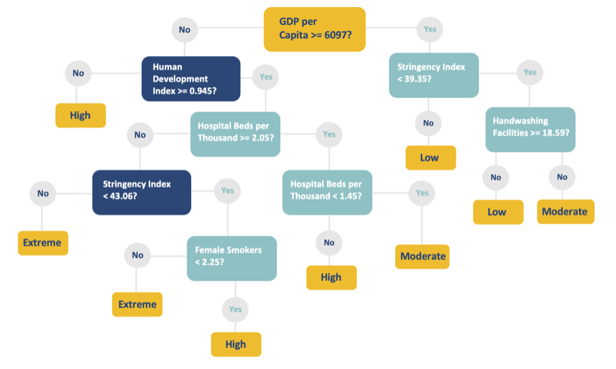